# Measurements - Session -2 : Python tutorial

I am using python version 3.9.12 for this tutorial. you can install python from [here](https://www.python.org/downloads/).

First of all I am importing all libraries that we need to do these activities. You have to install the following libraries to do this tutorial with pip. If you are an Anaconda user no need to install them. They are already installed with anaconda package.

I am doing this tutorial in jupyter note book. Therefore, I am using IPython library here. Others don't need it

To install those libraries open your terminal and run this code  
`pip install <library name>`

for example `pip install matplotlib`

```python
import numpy as np
import pandas as pd
import matplotlib.pyplot as plt
import librosa
import IPython.display as ipd

# no need to use this line if you don't use jupyter note book
%matplotlib inline

from statsmodels.tsa.ar_model import AutoReg
from sklearn.metrics import mean_squared_error
from math import sqrt
```

## Activity 14

#### The elevation of a cricket ball after it hits the ground (point G) is given in bit.ly/GP112_HAWKEYE . The ball hits the pad at a distance of 80 cm from the point G. If the wicket is at 120 cm from point G, calculate the elevation of the ball when it hits the wicket

I have converted the data given in this [google sheet](https://docs.google.com/spreadsheets/d/15pokbpj-LG3VP09K1BLSmAHFOiNmBhX12xps7dRG0Q0/edit#gid=0) into this [csv file](https://github.com/Rathees-Koneswarann/matplotlib-signal-analisis/blob/main/y-vs-time.csv). Let import the csv file and plot the graph for given data

```
x(n)     y(n)
0      0.000000
2      3.541725
4      6.726422
6      9.766844
8     13.082475
```

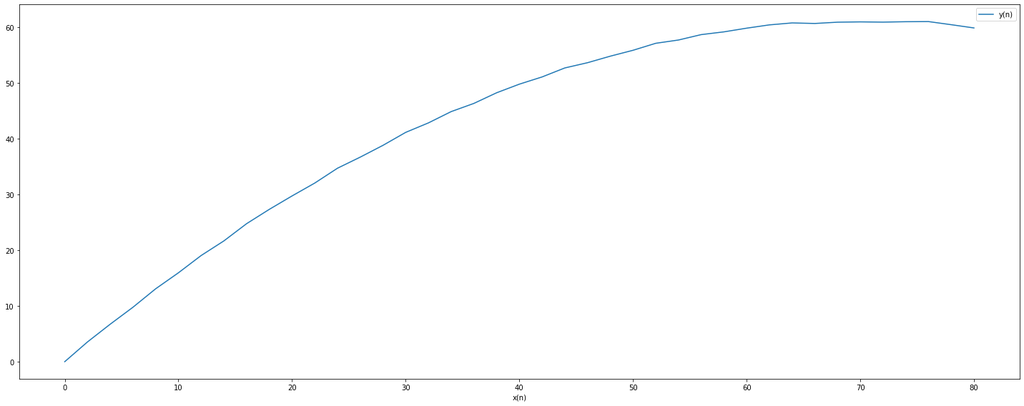

```python
plt.rcParams["figure.figsize"] = [20, 8]
plt.rcParams["figure.autolayout"] = True

# import the data sheet using pandas in csv format
given_data = pd.read_csv('y-vs-time.csv', header=0, index_col=0)
# import y(n) and x(n) for easy
given_data_y = pd.read_csv('y-vs-time.csv', usecols = ['y(n)'])
given_data_x = pd.read_csv('y-vs-time.csv', usecols = ['x(n)'])

# print first 5 raws in the data sheet
print(given_data.head())

# plot the data
given_data.plot()
plt.show()
```

We can plot the observation at the previous time step (t-1) with the observation at the next time step (t+1) as a scatter plot. from this visual check we can do to see if there is an autocorrelation in our time series dataset.

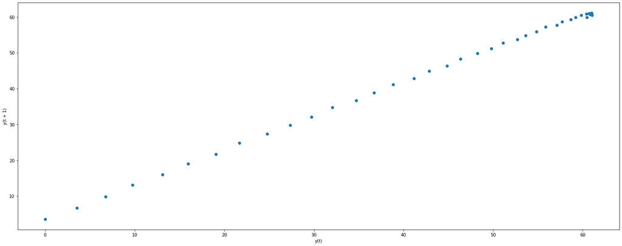

```python
pd.plotting.lag_plot(given_data)
plt.show()
```

We can see a diagonal line of the plot. It clearly shows a relationship or some correlation. Now we can predict the time series with AutoReg() function. Then we plot the old graph and new graph in same figure

```
Coefficients: [-0.96609082  0.32832503  0.3455879   0.18021577  0.16388366  0.06413512
  0.40027823  0.26511179 -0.27964289 -0.23322918 -0.23927604]

predicted = 59.452093
predicted = 58.884518
predicted = 58.323356
predicted = 57.705403
predicted = 56.855324
predicted = 55.745426
predicted = 54.649476
predicted = 53.559642
predicted = 52.461905
predicted = 51.295857
```

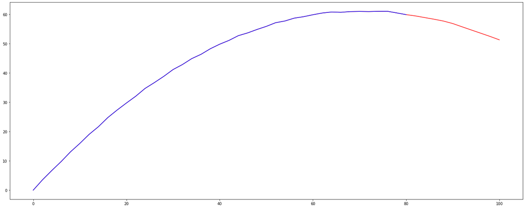

```python
# split dataset
Y = given_data_y.values
X = given_data_x.values

y_data = Y[0:len(Y)-10]
# y_data autoregression
model = AutoReg(y_data, lags=10)
model_fit = model.fit()
print('Coefficients: %s \n' % model_fit.params)
# make predictions
predictions = model_fit.predict(start=len(y_data), end=len(y_data)+9)
for i in range(len(predictions)):
	print('predicted = %f ' % (predictions[i]))


# plot results

plt.figure(figsize=(20,8))
merged_y_data = np.concatenate((y_data.flatten(),predictions))
plt.plot(X[0:len(X)], merged_y_data, 'red')
plt.plot(X[0:len(X)-10], y_data, 'blue')

plt.show()
```

[Download the final data sheet](https://github.com/Rathees-Koneswarann/matplotlib-signal-analisis/blob/main/final-data.csv)

## Activity 15

#### (a). Let N=5 and V = 0, 100, 80, 60, 40, 20 for h=0,1,2,3,4, and 5 respectively. Also let PIh = 0.1, 0.2, 0.3, 0.4, 0.5 for h=1,2,3,4 and 5 respectively. plot x(t).

Let f0 = 45

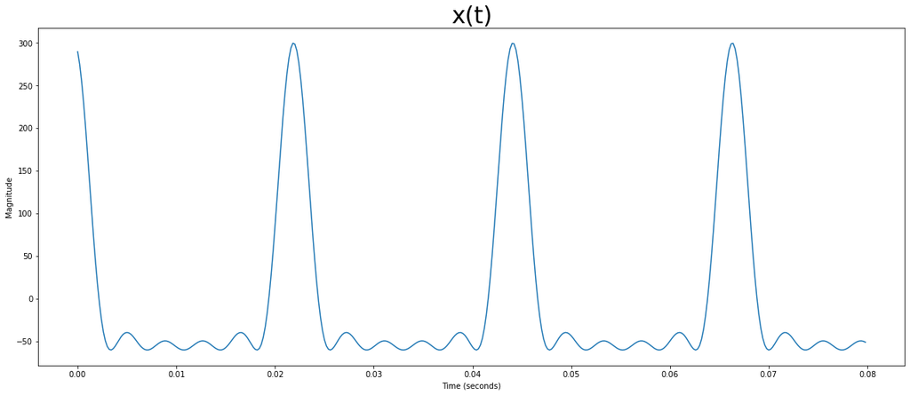

```python
# define the time axis
t = np.arange(0, 0.08 , 0.0002)

# define the initial values
f0 = 45
N = 5
y = 0
h = [1, 2, 3, 4, 5]
v = [100, 80, 60, 40, 20]
PIh = [0.1, 0.2, 0.3, 0.4, 0.5]

# loop indicater
i = 0

while i < N :
    # add signlas
    y += v[i]*np.cos(2*np.pi*h[i]*f0*t+PIh[i])

    i += 1

plt.figure(figsize=(20,8))
plt.plot(t,y)
plt.title('x(t)', fontsize = 30)
plt.xlabel('Time (seconds)')
plt.ylabel('Magnitude')
plt.show()
```

#### (b). Give plots for different values of V and PIh [at least 3 different plots]

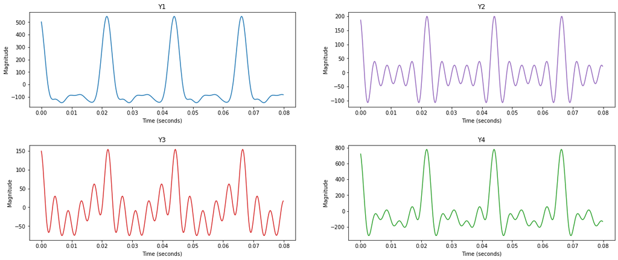

```python
# define the time axis
t = np.arange(0,0.08,0.0002)

# define the initial values
h = [1, 2, 3, 4, 5]
f0 = 45
N = 5

# define values for 4 different plots
v1 = [200, 180, 100, 50, 20]
PIh1 = [0.2, 0.3, 0.6, 0.8, 0.5]
v2 = [20, 30, 40, 50, 60]
PIh2 = [0.1, 0.2, 0.3, 0.4, 0.5]
v3 = [50, 15, 20, 25, 50]
PIh3 = [0.5, 0.3, 0.4, 0.3, 0.2]
v4 = [200, 180, 160, 140, 120]
PIh4 = [0.2, 0.7, 0.3, 0.4, 0.5]

# create 4 signals
y1 = 0
y2 = 0
y3 = 0
y4 = 0


# loop indicater
i = 0

while i < N :
    # add signals
    y1 += v1[i]*np.cos(2*np.pi*h[i]*f0*t+PIh1[i])
    y2 += v2[i]*np.cos(2*np.pi*h[i]*f0*t+PIh2[i])
    y3 += v3[i]*np.cos(2*np.pi*h[i]*f0*t+PIh3[i])
    y4 += v4[i]*np.cos(2*np.pi*h[i]*f0*t+PIh4[i])

    i += 1

# make subplots
fig, ax = plt.subplots(nrows=2, ncols=2, figsize=(20, 8),
                       gridspec_kw={
                        'width_ratios': [3, 3],
                        'height_ratios': [3, 3],
                        'wspace': 0.2,
                        'hspace': 0.4})
ax[0, 0].plot(t, y1)
ax[0, 1].plot(t, y2, 'tab:purple')
ax[1, 0].plot(t, y3, 'tab:red')
ax[1, 1].plot(t, y4, 'tab:green')

# add titles
ax[0, 0].set_title("Y1")
ax[0, 1].set_title("Y2")
ax[1, 0].set_title("Y3")
ax[1, 1].set_title("Y4")

# add labels
for axs in ax.flat:
    axs.set(xlabel='Time (seconds)', ylabel='Magnitude')



plt.show()
```

## Activity 17

#### [a]. Calculate the amplitude V and phase Pih for frequency component corresponding to the frequency hf0 , where h=1,2,3...6 considering one cycle of the waveform of a violin. File can be found at [here](https://github.com/Rathees-Koneswarann/matplotlib-signal-analisis/blob/main/violin-C4.wav)

you can download the wave file from this [link](https://github.com/Rathees-Koneswarann/matplotlib-signal-analisis/blob/main/violin-C4.wav). It is 260 Hz, C4 note file. Let check the sample rate of the audio file and number of samples

```python
#load .wav sound file
#sr = sample rate = #sample per second, 22050 Hz
x, sr = librosa.load('violin-C4.wav')
x = x[0:(3*sr)+1]
print(type(x))
print('x length: {}'.format(len(x)))
print(type(sr))
print('sr = {}'.format(sr))
```

```
<class 'numpy.ndarray'>
x length: 66151
<class 'int'>
sr = 22050
```

Now, get the lenght of sound clip in integer

```python
# confirm the audio sample length
print('Sound clip is {} seconds long.'.format((len(x)-1)/sr))
```

```
Sound clip is 3.0 seconds long.
```

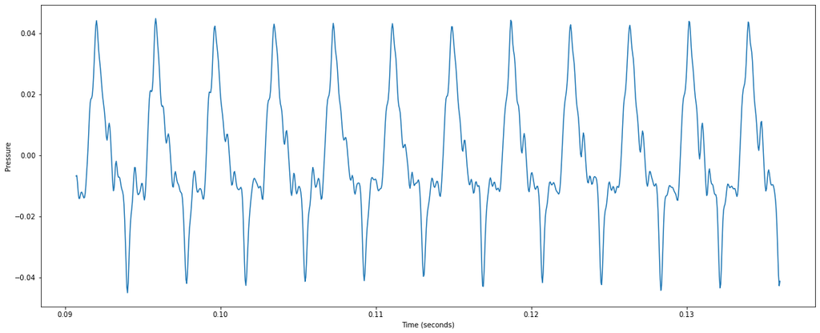

```python
plt.figure(figsize=(20,8))
# Develop array 't to match x
t = np.array(range(0, len(x)))/sr
#plt.plot(t,x)
plt.plot(t[2000:3000],x[2000:3000])
plt.xlabel('Time (seconds)')
plt.ylabel('Pressure')
```

I embad the audio file here with Ipython.

```python
ipd.Audio(x ,rate = sr)
```

[interactive chart not shown]

Now we will do the fourier transformation

```python
# find the fourier transform
c = np.fft.fft(x)
print(type(c))
print(len(c))
#print the array of complex numbers
print(c[0:10])
```

```
<class 'numpy.ndarray'>
66151
[-105.52198595-3.10862447e-15j    4.50358546-4.71183184e+00j
    2.83387104-3.87256720e+00j    1.89096091-4.07505836e+00j
    0.64015351-4.07604171e+00j   -0.29418841-3.45535666e+00j
   -0.84512789-2.92568689e+00j   -1.07781596-2.38081172e+00j
   -1.21083966-1.95421703e+00j   -1.26617415-1.64000292e+00j]
```

Let plot the Frequency vs Amlitude Graph for whole range

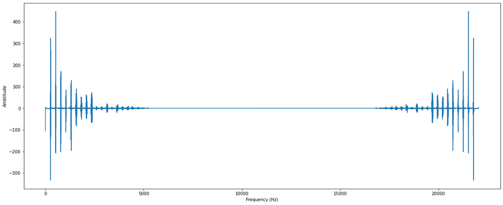

```python
fr = np.array(range(0,66151))/3
# plot the absolute value
plt.figure(figsize=(20,8))
plt.plot(fr,c)
plt.xlabel('Frequency (Hz)')
plt.ylabel('Amblitude')
```

Following code will give you the absolute magnitude

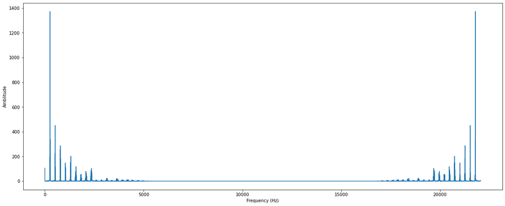

```python
fr = np.array(range(0,66151))/3
# plot the absolute value
plt.figure(figsize=(20,8))
plt.plot(fr,np.abs(c))
plt.xlabel('Frequency (Hz)')
plt.ylabel('Amblitude')
```

Since we need the plot for specific range, we can change the range and plot it again

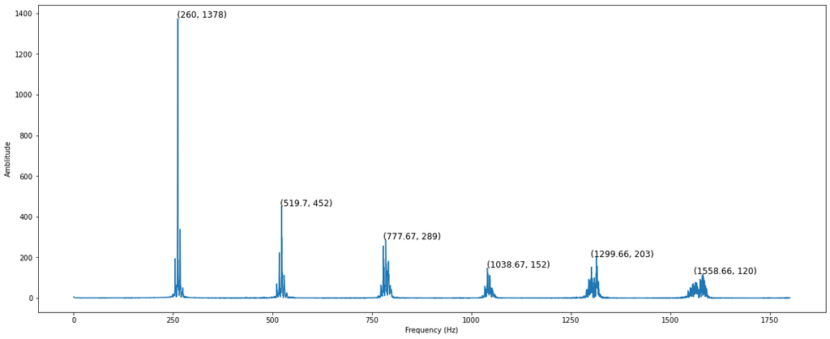

```python
fig, ax = plt.subplots(figsize=(20,8))
condition = (fr >0) & (fr < 1800)
plt.plot(fr[condition],np.abs(c[condition]))
plt.xlabel('Frequency (Hz)')
plt.ylabel('Amblitude')
ax.text(260, 1378, '(260, 1378)', size=12)
ax.text(519.7, 452, '(519.7, 452)', size=12)
ax.text(777.67, 289, '(777.67, 289)', size=12)
ax.text(1038.67, 152, '(1038.67, 152)', size=12)
ax.text(1299.66, 203, '(1299.66, 203)', size=12)
ax.text(1558.66, 120, '(1558.66, 120)', size=12)
```

Let Plot Frequency vs Phase graph

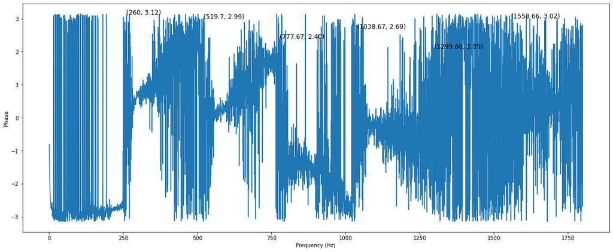

```python
fig, ax = plt.subplots(figsize=(20,8))
condition = (fr >0) & (fr < 1800)
plt.plot(fr[condition],np.angle(c[condition]))
plt.xlabel('Frequency (Hz)')
plt.ylabel('Phase')
ax.text(260, 3.12, '(260, 3.12)', size=12)
ax.text(519.7, 2.99, '(519.7, 2.99)', size=12)
ax.text(777.67, 2.40, '(777.67, 2.40)', size=12)
ax.text(1038.67, 2.69, '(1038.67, 2.69)', size=12)
ax.text(1299.66, 2.09, '(1299.66, 2.09)', size=12)
ax.text(1558.66, 3.02, '(1558.66, 3.02)', size=12)
```

Zoomed frequency vs phase graph

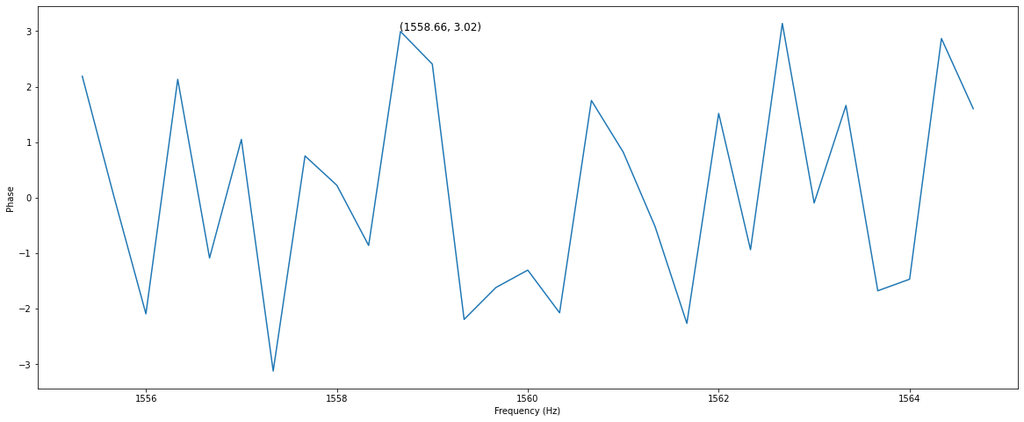

```python
fig, ax = plt.subplots(figsize=(20,8))
condition = (fr >1555) & (fr < 1565)
plt.plot(fr[condition],np.angle(c[condition]))
plt.xlabel('Frequency (Hz)')
plt.ylabel('Phase')
ax.text(1558.66, 3.02, '(1558.66, 3.02)', size=12)
```